# Linear Regression with Survey Data

PUBHBIO 7225 Lecture 20

Generative AI acknowledgment: Google Gemini was used to assist in generating alt text for most images

## Outline

**Topics**

- Linear regression with survey data (from a probability sample)

**Activities**

- 20.1 Linear Regression with NHANES

**Readings**

- See last slide for optional readings (PDFs on Carmen)

**Assignments**

- Problem Set 5 (last one!) due Thursday 11/13/2025 11:59pm via Carmen  
  (this will be graded by Dr Andridge, not peer reviewed)
- Quiz 5 (last one!) due Thursday 11/20/2025 11:59pm via Carmen

## Regression With Survey Data

- Until now, we’ve estimated **totals**, **means**, and **proportions**, for a population or subpopulation
- For these types of estimates, it is (hopefully by now) obvious why we need to use weights to account for the survey design
- For analyses that evaluate **relationships** among variables (e.g., regression) the issue is less straightforward
- **Broad generality:** weighting “matters” more for estimating marginal quantities (means/proportions/totals) than it does for estimating relationships between/among variables (like via regression)
- **Thought experiment:**
  - I want to learn about student loan balances among OSU students
  - I sample students via a design that *oversamples* students from out of state (who pay higher tuition)
  - If I ignore the design and estimate the following quantities, under what situations might they be biased?
    - Mean loan balance, population of *all* OSU students
    - Mean loan balance, population of OSU students *from outside Ohio* (out-of-state)
    - *Difference* in mean loan balance between in-state and out-of-state students

## Does Weighting Matter for Regression?

- **Unweighted** regression estimator is unbiased for true linear regression parameters if:
  - Mean model is **correctly specified**, (correctly specified $X$s), and
  - Sampling is **ignorable** – meaning that $Z_i \perp\!\!\!\!\perp y | x$
- **Weighted** regression estimator protects us if one of these conditions is not met
  - If model is **not correctly specified**, weighted estimates give us an unbiased estimate of the mis-specified relationship (whereas unweighted estimates would be biased)
    - Ex: True relationship quadratic, but you model as linear – weights give you the best estimate of that incorrectly specified relationship (best linear approximation to the quadratic relationship)
  - If sampling is **non-ignorable**, unweighted estimates will generally be biased, but weighted estimates will be unbiased
    - Need the weights to properly account for sampling design since $Z$ is related to $y$
- Should we always use weighted regression?
  - Penalty for doing weighted regression = loss of efficiency (larger variances) when model is correctly specified and sampling is ignorable

## Example: 1988 NMIHS

- Classic example: Gestational age (GA) and birthweight (BW) in the 1988 National Maternal and Infant Health Survey (NMIHS)
  - NMIHS = Probability sample of babies whose mothers were aged 15 and older in the U.S.
  - Oversampled African-American and low-birthweight babies
  - Sample size roughly 10,000 babies
- Comparing weighted and unweighted analysis using BW (g) to predict GA (weeks):

| Parameter | Weighted Estimate (SE) | Unweighted Estimate (SE) |
| --- | --- | --- |
| Intercept | 32.08 (.17) | 26.36 (.14) |
| Birthweight (g) | .00215 (.00005) | .00383 (.00005) |

- **Weighted**: 100 gram reduction in BW associated with a 0.215 week (1.5 day) decrease in GA
- **Unweighted**: 100 gram reduction in BW associated with a 0.383 week (2.7 day) decrease in GA
  - Quite different results! Why?

## Example (con’t)

- Difference is due to the **non-linearity** in the birthweight-gestational age association and the **oversampling of low birthweight babies**

**Unweighted**

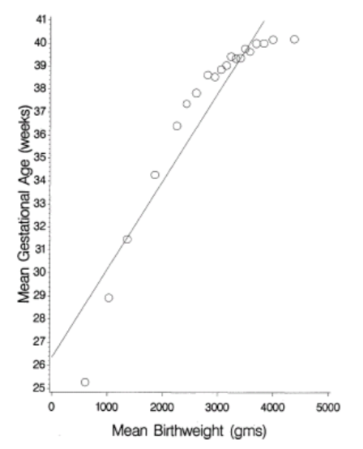

**Weighted**

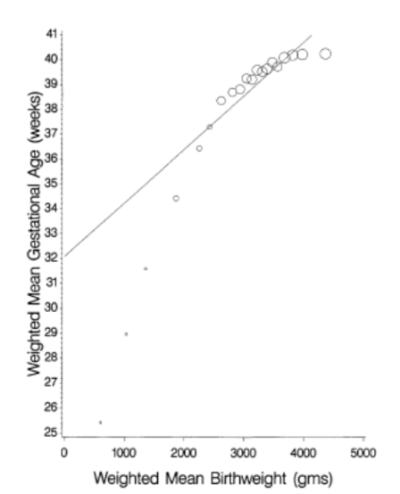

- True relationship appears to be *quadratic* – but model misspecified as *linear*
- Weighted model estimates give the best estimate of the linear approximation
- Alternative: include a quadratic term in the model (thus weighted $\approx$ unweighted)

## Conditioning on Design Variables

- One approach: include **all design variables as predictors**, along with any variables involved in creating the weights, and use **unweighted regression**
  - This by definition makes the sampling **ignorable**
    - $Z \perp\!\!\!\!\perp y|x$ if $x$ determines $Z$!
  - This would potentially mean including in the model:
    - Stratum indicators
    - Cluster indicators (via random effects, perhaps)
    - Variables involved in nonresponse adjustments, poststratification/raking, etc.
  - A daunting task, especially for surveys with complex designs and post-survey weight adjustments
- If it can be done, regression coefficient estimates and SEs will be **unbiased**

## Conditioning on Design Variables (con’t)

- Sometimes (often), however, **true** design variables are **not provided to end users**, or weights are otherwise manipulated
  - “Pseudo-strata” instead of the true strata
  - “Masked variance units (MVUs)” = “Pseudo-PSUs” instead of of the true PSUs
- Additional manipulations to weights also common
  - Weight trimming methods (truncating very large weights) can’t easily be incorporated
- So this approach isn’t actually possible most of the time with publicly available data

## Design Variable as the Outcome

- Sometimes we might be interested in predictors of a variable that was used in the sampling design
- Example: Birthweight (BW) and smoking in the 1988 NMIHS
  - Comparing weighted and unweighted analysis using maternal smoking status to predict BW (g) using ANCOVA:

    | Mother Smoked? | Weighted Mean (SE) | Unweighted Mean (SE) |
    | --- | --- | --- |
    | No | 3409 (8.0) | 2923 (12) |
    | Yes | 3232 (12) | 2664 (18) |
    | Difference | 177 (15) | 260 (21) |

  - Difference between weighted and unweighted is due to the **oversampling of low birthweight babies**
  - Can’t “adjust this away” with predictors – because the outcome (birthweight) is the design variable!

## How Do I Know If Weighting Matters for MY Regression?

- General consensus is you should use weights in the regression when:
  - The weight is a function of the dependent (outcome) variable
  - You don’t know enough about how the weights were constructed  
    (may be the case for some publicly available datasets)
  - Large sample size – even if weights are not strictly necessary, the loss of power from using weights won’t be as much of a concern
- Possible ways to check to see if weighted regression is necessary:
  - Perform both weighted and unweighted regressions, and compare coefficients estimates
    - If not significantly different, weights not necessary
  - Add the weight and an interaction of the weight with each predictor to the model
    - If coefficients of weights and interactions are not significant, weights not necessary
- Remember: If weights “don’t matter” for regression estimates, penalty for using weighted regression anyway is a loss of efficiency (variance too large) – might not be a big deal with a large sample size (like many surveys)

## Details: What IS Weighted Regression?

- From a finite population perspective, linear regression is a fitting of a line to a finite population of $N$ units
  - Describing the relationship between outcome $y$ and predictor $x$ in a finite set of units
- Thinking specifically about a simple linear regression model, we have the best fitting **least squares** regression line:
  $$y = B_0 + B_1 x$$
  - $B_0$ and $B_1$ are the coefficients that minimize the quantity:
    $$\sum_{i =1}^N (y_i - B_0 - B_1 x_i)^2$$

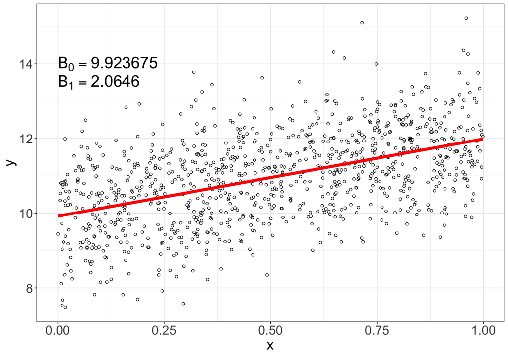

- There is **no assumption of normality** and **no assumption about (equal) variance**
  - A line describes the relationship between $x$ and $y$ in the finite population, and we take a sample from the population to use to estimate this line

## Details (con’t)

- Closed-form expressions for $B_0$ and $B_1$ are:

$$\begin{aligned}
\text{Slope: }B_1 &= \frac{\sum_{i=1}^N x_i y_i - \frac{1}{N} \left(\sum_{i=1}^N x_i \right) \left(\sum_{i=1}^N y_i\right)}{\sum_{i=1}^N x_i^2 - \frac{1}{N} \left(\sum_{i=1}^N x_i \right)^2} &= \frac{t_{xy} - \frac{t_x t_y}{N}}{t_{x^2} - \frac{(t_x)^2}{N}}\\
\text{Intercept: }B_0 &= \frac{1}{N} \sum_{i=1}^N y_i - B_1 \frac{1}{N} \sum_{i=1}^N x_i &= \frac{t_y-B_1 t_x}{N}
\end{aligned}$$

- These are functions of **totals** – and we know how to estimate totals from any complex sampling design!

$$\begin{aligned}
\hat{B}_1 &= \frac{\hat{t}_{xy} - \frac{\hat{t}_x \hat{t}_y}{\hat{N}}}{\hat{t}_{x^2} - \frac{(\hat{t}_x)^2}{\hat{N}}} = \frac{\sum_{i \in \mathcal{S}} w_i x_i y_i - \frac{\left(\sum_{i \in \mathcal{S}} w_i x_i \right) \left(\sum_{i \in \mathcal{S}} w_i y_i\right)}{\sum_{i \in \mathcal{S}} w_i} }{\sum_{i \in \mathcal{S}} w_i x_i^2 - \frac{\left(\sum_{i \in \mathcal{S}} w_i x_i \right)^2}{\sum_{i \in \mathcal{S}} w_i} } \\
\hat{B}_0 &= \frac{\hat{t}_y-\hat{B}_1 \hat{t}_x}{\hat{N}} = \frac{\sum_{i \in \mathcal{S}} w_i y_i - \hat{B}_1\sum_{i \in \mathcal{S}} w_i x_i}{\sum_{i \in \mathcal{S}} w_i}
\end{aligned}$$

## Details (con’t)

- Clearly in practice you wouldn’t hand-calculate these
  - In fact, software uses better algorithms that aren’t subject to as much potential rounding error
- Also – we need standard errors!
- Once again we can use **linearization** to estimate standard errors
  - $\hat{B}_0, \hat{B}_1$ are non-linear functions of totals
  - Use linearization to approximate these quantities as linear functions of totals
  - Then, estimate the variance of this linear quantity – since we know how to estimate the variance for a total from any complex sample design
- Use SEs to compute CIs and perform hypothesis tests (e.g., Wald tests for regression coefficients)

## Details (con’t)

- **Note #1: Subtle difference in CI interpretation from infinite population inference**
  - With a design-based CI, the confidence level (e.g., 95%) for a coefficient (say, $B_1$) is the sum of the probabilities of all possible samples $\mathcal{S}$ that could be taken with the specified design for which the CI constructed from that sample will contain the true $B_1$
- **Note #2: Survey-Weighted Regression is not Weighted Least Squares (WLS)**
  - The point estimates you get from survey weighted linear regression will be the **same as** point estimates from WLS – but the standard errors **will not be the same**.
  - We need the linearization estimator to properly account for the sample design

## Degrees of Freedom

- In the **infinite population** setting:
  - Estimating a mean: DF = $n-1$
  - Estimating a regression coefficient: DF = $n-1-p$ ($p$ = # coefficients excluding the intercept)
- For **finite population** sampling:
  - Estimating a mean: DF = # PSUs $-$ # Strata
  - Estimating a regression coefficient:
    - **Option 1:** DF = # PSUs $-$ # Strata $-$ $p$
    - **Option 2:** DF = # PSUs $-$ # Strata (no extra subtraction of $p$)
- **Option 1** is:
  - *Correct* if all covariates are *PSU-level*
  - *Very conservative* if covariates are *SSU-level*
- Different software does different things by default…
- Sometimes (for designs with small DF) these differences in DF can result in observably different p-values

## Example (con’t)

**DF** = # PSUs $-$ # Strata = 37

```r
summary(fit_samp, df.resid=degf(des))
```

```
Call:
svyglm(formula = api00 ~ ell + stype, design = des)

Survey design:
svydesign(id = ~dnum + snum, weight = ~wt, fpc = ~N + Mi, data = samp)

Coefficients:
            Estimate Std. Error t value Pr(>|t|)
(Intercept) 797.7698    27.6790  28.822  < 2e-16 ***
ell          -4.5490     0.4874  -9.333 2.91e-11 ***
stypeM      -92.7395    29.5132  -3.142  0.00329 **
stypeH      -42.5118    26.6213  -1.597  0.11879
---
Signif. codes:  0 '***' 0.001 '**' 0.01 '*' 0.05 '.' 0.1 ' ' 1

(Dispersion parameter for gaussian family taken to be 4304.603)

Number of Fisher Scoring iterations: 2
```

**DF** = # PSUs $-$ # Strata $-$ $p$ = 34

```r
summary(fit_samp)
```

```
Call:
svyglm(formula = api00 ~ ell + stype, design = des)

Survey design:
svydesign(id = ~dnum + snum, weight = ~wt, fpc = ~N + Mi, data = samp)

Coefficients:
            Estimate Std. Error t value Pr(>|t|)
(Intercept) 797.7698    27.6790  28.822  < 2e-16 ***
ell          -4.5490     0.4874  -9.333 6.63e-11 ***
stypeM      -92.7395    29.5132  -3.142  0.00346 **
stypeH      -42.5118    26.6213  -1.597  0.11954
---
Signif. codes:  0 '***' 0.001 '**' 0.01 '*' 0.05 '.' 0.1 ' ' 1

(Dispersion parameter for gaussian family taken to be 4304.603)

Number of Fisher Scoring iterations: 2
```

- The $t$-distributions with 34 and 37 are pretty similar, doesn’t make much difference which DF you use
- But in a design with fewer PSUs, it might matter more

## References for Futher Reading

- Interested in more perspectives on whether or not to use weights in analyzing survey data?
  - Bollen KA, Biemer PP, Karr AF, Tueller S, and Berzofsky ME. (2016) Are survey weights needed? A review of diagnostic tests in regression analysis. *Annual Review of Statistics and Its Application*, 3:375-392.
  - Solon G, Haider SJ, and Wooldridge JM (2015). What are we weighting for? *J. Human Resources*, 50:301-316
  - Gelman A (2007). Struggles with survey weighting and regression modeling. *Statistical Science*, 22(2):153-164
  - Winship C and Radbill L (1994). Sampling weights and regression analysis. *Sociological Methods and Research*, 23:230-257

(PDFs on Carmen)

- Final thought: **USE SURVEY-WEIGHTED REGRESSION**

## Activity 20.1

Linear Regression with NHANES